# Height and Weight: Actual vs Reported

Layne Looney

## Introduction

In this report, my subject of interest is how people report their height and weight in comparison to what those numbers actually are. My first hypothesis is that weight will have a larger differnce between actual and reported than height will. My second hypothesis is that males will report a larger number for their height than what it is. My third hypothesis is that females will report a lower number for their weight than what it is.

## Methods

To obtain this dataset, I went online and found a 200 person sample. I then checked for errors and created a CSV with the data. Height is in cm and weight is in kg. The models used here are able to create a mean and then compare it to another mean or multiple other means.Then the model describes the best fit line for the data.

## Results

```
##
## Call:
## lm_basic(formula = repht ~ 1 + height, data = reported)
##
## Residuals:
##     Min      1Q  Median      3Q     Max
## -7.9148 -1.2729 -0.0541  1.7122  7.9061
##
## Coefficients:
##             Estimate    2.5 % 97.5 %
## (Intercept)  -5.2684 -10.9787  0.442
## height        1.0199   0.9865  1.053
##
## Residual standard error: 2.136 on 198 degrees of freedom
## Multiple R-squared:  0.9481, Adjusted R-squared:  0.9479
## F-statistic:  3619 on 1 and 198 DF,  p-value: < 2.2e-16
```

```
##
## Call:
## lm_basic(formula = repwt ~ 1 + weight, data = reported)
##
## Residuals:
##     Min      1Q  Median      3Q     Max
## -6.9513 -1.0277  0.0365  1.0426  8.6329
##
## Coefficients:
##             Estimate   2.5 % 97.5 %
## (Intercept)  -0.7580 -2.3113  0.795
## weight        1.0122  0.9889  1.036
##
## Residual standard error: 2.223 on 198 degrees of freedom
## Multiple R-squared:  0.9737, Adjusted R-squared:  0.9735
## F-statistic:  7324 on 1 and 198 DF,  p-value: < 2.2e-16
```

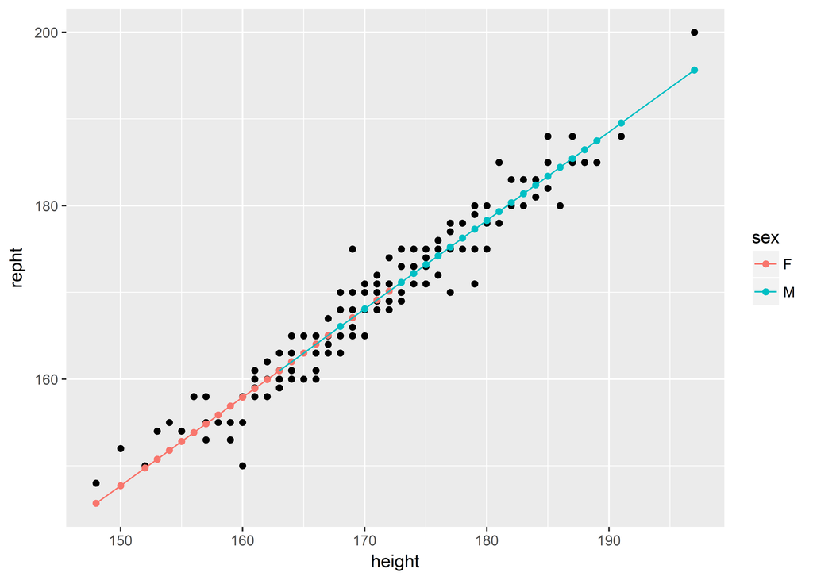

Notice here the difference between the best fit line and the line in the graphic below this.

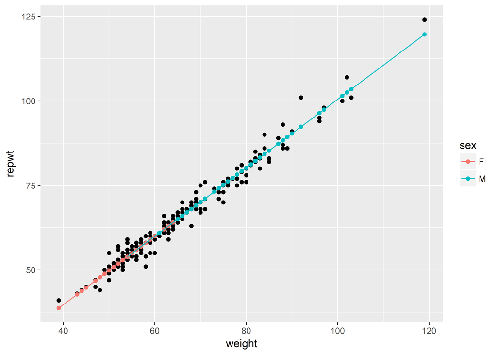

There is almost no difference in weight versus the graphic above which shows height.

```
##
## Call:
## lm_basic(formula = repht ~ 1 + height, data = male)
##
## Residuals:
##     Min      1Q  Median      3Q     Max
## -6.4225 -1.4278 -0.3973  1.5822  5.5733
##
## Coefficients:
##             Estimate    2.5 % 97.5 %
## (Intercept)  -1.9534 -15.0325 11.126
## height        1.0021   0.9287  1.076
##
## Residual standard error: 2.219 on 86 degrees of freedom
## Multiple R-squared:  0.8954, Adjusted R-squared:  0.8942
## F-statistic: 736.1 on 1 and 86 DF,  p-value: < 2.2e-16
```

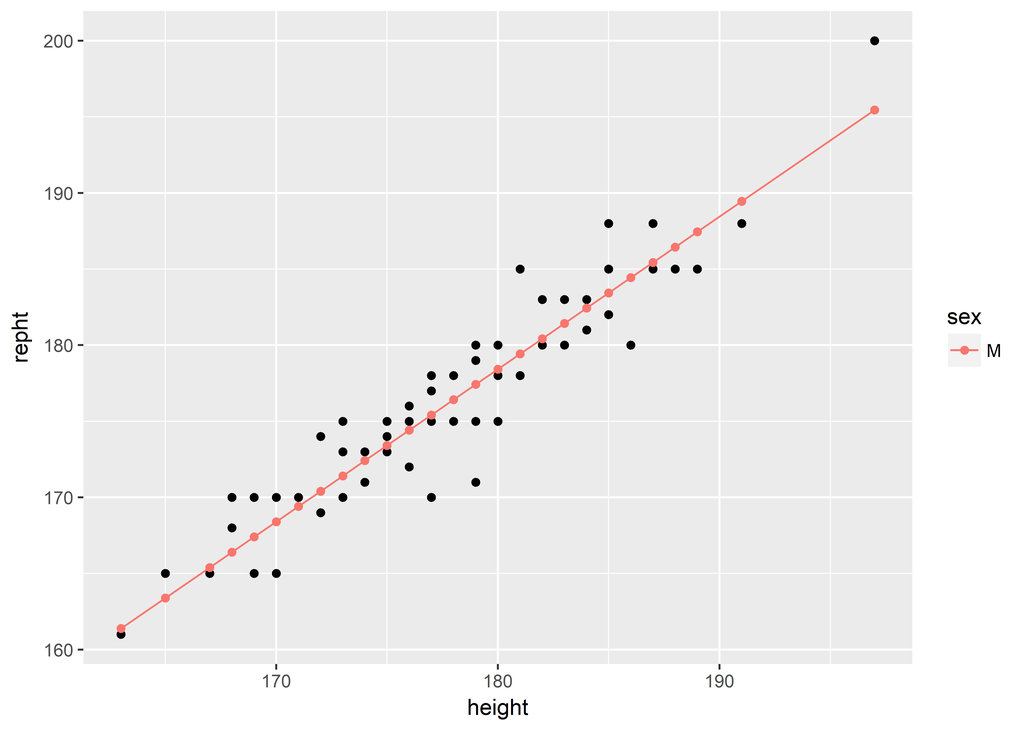

```
##
## Call:
## lm_basic(formula = repwt ~ 1 + weight, data = female)
##
## Residuals:
##     Min      1Q  Median      3Q     Max
## -6.5426 -0.8246  0.1256  1.1222  5.1919
##
## Coefficients:
##             Estimate  2.5 % 97.5 %
## (Intercept)   3.3918 0.3526  6.431
## weight        0.9336 0.8806  0.987
##
## Residual standard error: 1.934 on 110 degrees of freedom
## Multiple R-squared:  0.9171, Adjusted R-squared:  0.9164
## F-statistic:  1217 on 1 and 110 DF,  p-value: < 2.2e-16
```

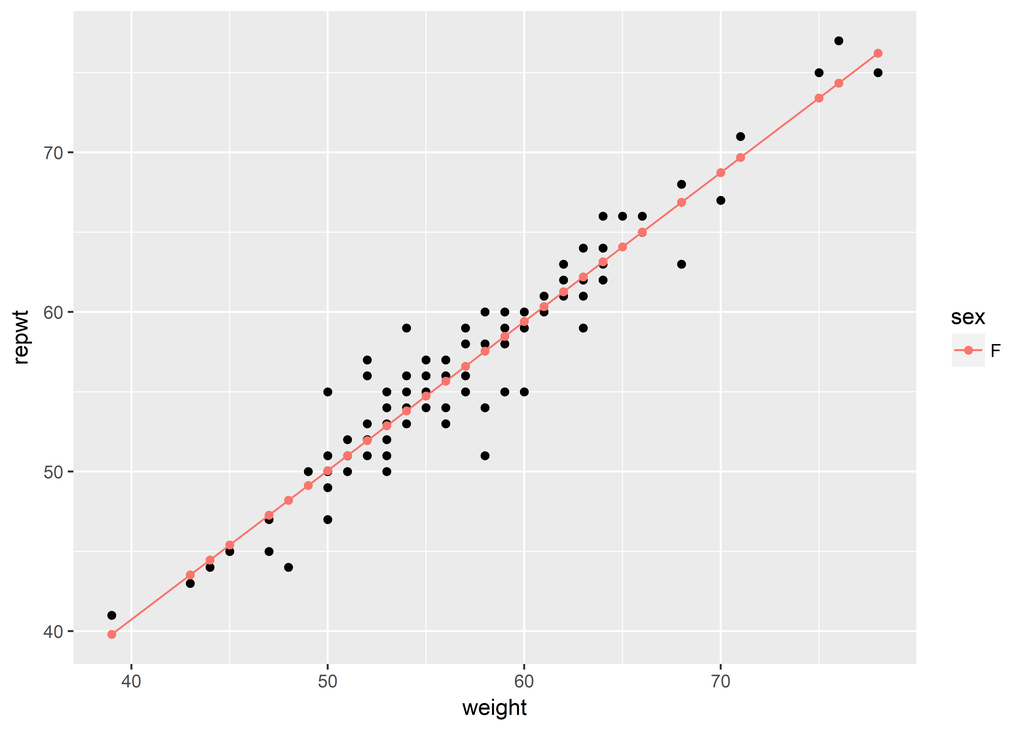

Females, according to the best fit line, are fairly accurate when it comes to telling their actual weight.

## Conclusions

In hypothesis 1, the difference between weight and height came down to the intercepts, as the slopes, representing actual height and weight repsectively, were nearly identitical. Both intercepts, representing the reported height and weight repsectively, were not significant at a 95% confidence level, which means that there is not a significant difference between difference of the two measures.

In hypothesis 2, the same problem arose. The slope here was roughly a 1, representing actual height, and was considered significant at a 95% confidence level. But the intercept, representing reported height, was not significant, which means that there is not significant data that proves men will overstate or understate their height. This large range in reported height shows that there is not much of a trend going in one way or another when it comes to men overstating or understating their height.

In hypothesis 3, the numbers were different. At a 95% confidence level, both the slope (actual weight) and the intercept (reported weight) were significant. This means that womens’ reported weight was higher than what it actually was, which disproves this hypothesis. However, as the weight gets higher, the reported weights begin to drop from overstating to understating which proves the hypothesis. Therefore the linear regression proves the hypothesis at higher weights, but not at lower weights.

## References

http://wiki.stat.ucla.edu/socr/index.php/SOCR_Data_Dinov_020108_HeightsWeights